# Assignment 5

Alessandro Riboni

14 giugno 2019

# Decision Models - Reinforcement Learning assignment

Consider the deterministic setting reported in the following figure. There are 8 different states:

- One initial state (where the 0 is)
- Six “intermediate” states (from 1 to 6)
- One final state (where the casa is)

At all states, but the final one, a decision must be taken, according to two different options: going right or going left.

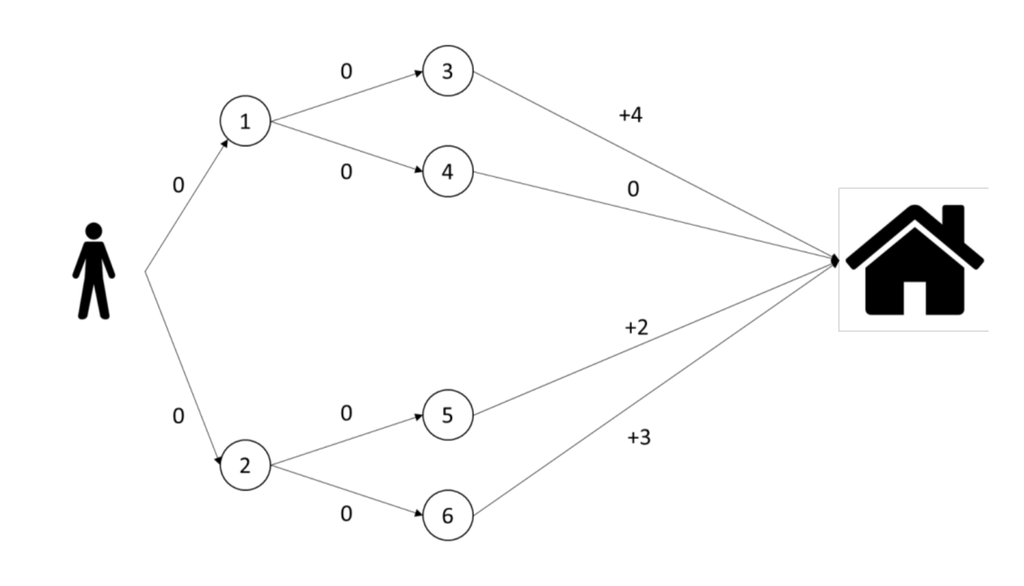

The following initial policy $\pi_0$ is given:

- 0 $\rightarrow$ 2
- 2 $\rightarrow$ 5
- 1 $\rightarrow$ 4
- (from 3, 4, 5, and 6 only one action is possible, leading to home, that is the final state)

### 1. Compute the state function $V^{\pi_0}$ for each state

Per calcolare la state function abbiamo utilizzato la seguente formula:
$$V^*(s)= max_{\alpha \in A}[R(s,a)+\gamma V^*(s')]$$
con $\gamma$ (discount factor) uguale a 1.

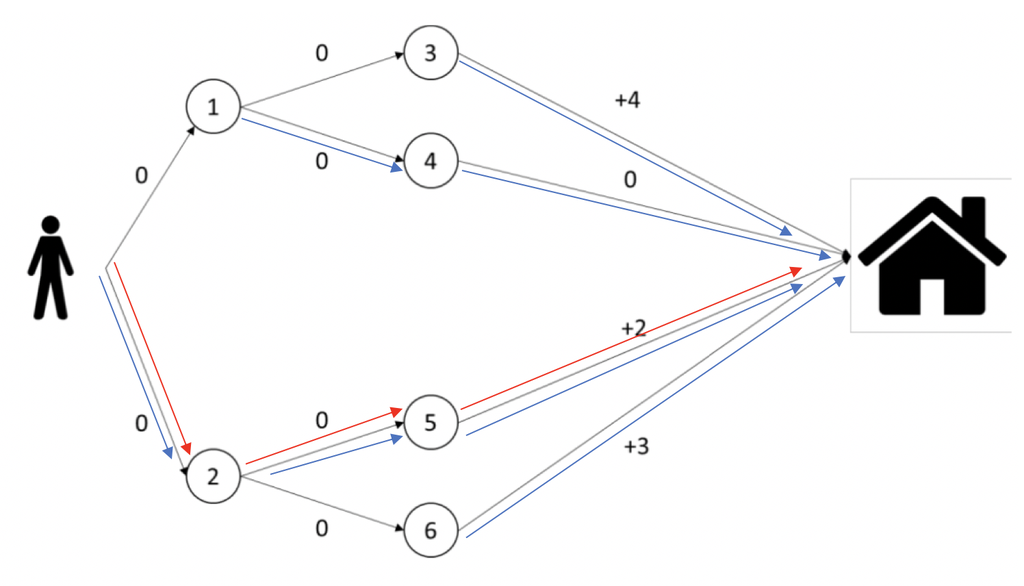

Le freccie blu rappresentano la policy $\pi_0$, mentre le freccie rosse rappresentano il percorso che massimizza la reward in base alla policy $\pi_0$.  
In questo caso, il percorso rosso è:

- 0 $\rightarrow$ 2
- 2 $\rightarrow$ 5
- 5 $\rightarrow$ casa

La reward è uguale a 2.

### 2. Improve the policy to obtain the new $\pi_1$

La policy improvement $\pi'(s)$ è:
$$\pi'(s)= argmax_{\alpha \in A}E[R(s,a)+\gamma V^{\pi}(s')]$$
Come fatto in precedenza, la new policy $\pi_1$ è:

- 0 $\rightarrow$ 2
- 2 $\rightarrow$ 6
- 1 $\rightarrow$ 3
- (da 3, 4, 5, a 6 l’unica azione possibile è raggiungere casa, ovvero lo stato finale).

### 3. Compute the new state function $V^{\pi_1}$

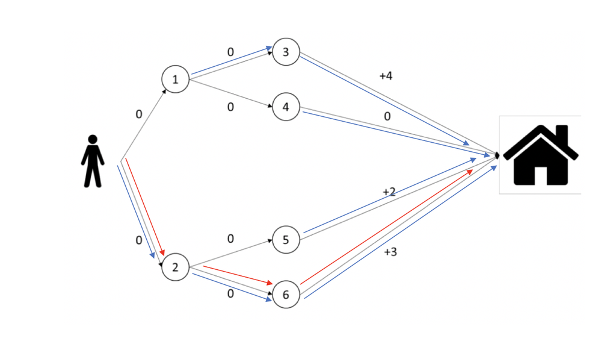

- 0 $\rightarrow$ 2
- 2 $\rightarrow$ 6
- 6 $\rightarrow$ casa

La reward è uguale a 3.

### 4. Improve the new policy to obtain the new $\pi_2$

La policy improvement $\pi'(s)$ è:
$$\pi'(s)= argmax_{\alpha \in A}E[R(s,a)+\gamma V^{\pi}(s')]$$

- 0 $\rightarrow$ 1
- 2 $\rightarrow$ 6
- 1 $\rightarrow$ 3
- (da 3, 4, 5, a 6 l’unica azione possibile è raggiungere casa, ovvero lo stato finale)

Calcoliamo la state function $V^{\pi_2}$ per ogni stato:

- $V^{\pi_2}(0) = max(0+0+4,0+0+3) = 4$
- $V^{\pi_2}(1) = max( 0+4, 0+0) = 4$
- $V^{\pi_2}(2) = max(0+2, 0+3) = 3$
- $V^{\pi_2}(3) = 4$
- $V^{\pi_2}(4) = 0$
- $V^{\pi_2}(5) = 2$
- $V^{\pi_2}(6) = 3$
- $V^{\pi_2}(casa) = 0$

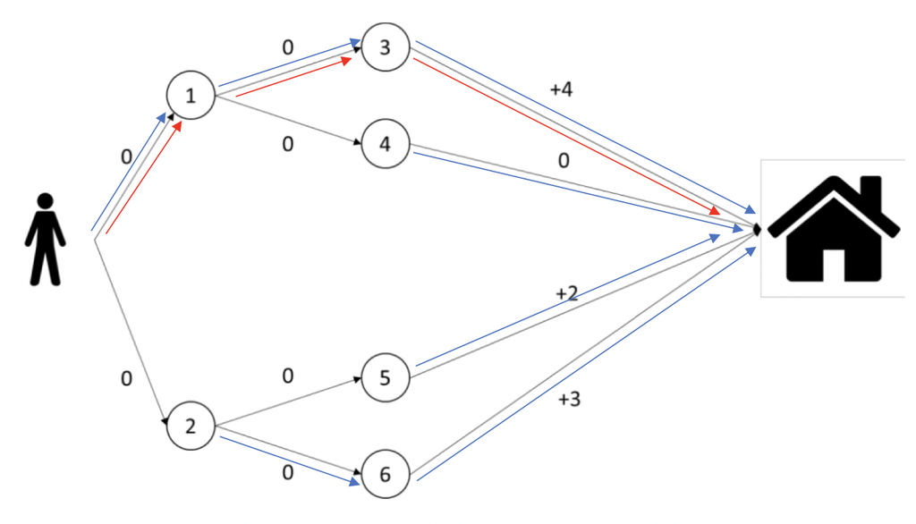

- 0 $\rightarrow$ 1
- 1 $\rightarrow$ 3
- 3 $\rightarrow$ casa

La reward è uguale a 4.

### Did you converge to the optimal policy?

Per verificare la convergenza alla policy ottimale, la policy $\pi_2$ deve essere uguale alla policy $\pi_3$. La nuova policy $\pi_3$ è:

- 0 $\rightarrow$ 1
- 2 $\rightarrow$ 6
- 1 $\rightarrow$ 3
- (da 3, 4, 5, a 6 l’unica azione possibile è raggiungere casa, ovvero lo stato finale)

Calcoliamo la state function $V^{\pi_3}$ per ogni stato:

- $V^{\pi_3}(0) = max(0+0+4,0+0+3) = 4$
- $V^{\pi_3}(1) = max( 0+4, 0+0) = 4$
- $V^{\pi_3}(2) = max(0+2, 0+3) = 3$
- $V^{\pi_3}(3) = 4$
- $V^{\pi_3}(4) = 0$
- $V^{\pi_3}(5) = 2$
- $V^{\pi_3}(6) = 3$
- $V^{\pi_3}(casa) = 0$

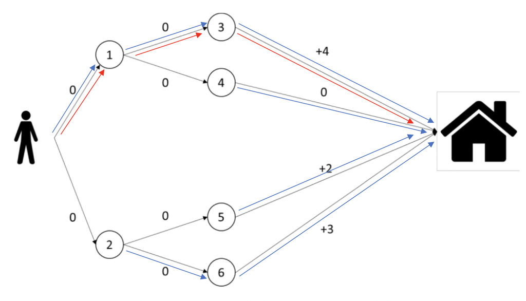

Come si può notare, la nuova policy è uguale a quella precedente e la reward rimane uguale a 4.  
Possiamo perciò concludere che la policy $\pi_2$ converge alla policy ottimale.